# Topic 5 Problem Set

Xue (Tracy) Feng

## Preparation

```r
library(tidyverse)
library(tidytext)
library("sentimentr")
library(wordcloud)
```

The `sentimentr` package includes several text data sets. For this exercise use the “hotel_reviews” data. This data set contains 5,000 hotel reviews scraped from TripAdvisor. It also contains a sentiment score for each review, a score produced via automated sentiment analysis.

Access this data by installing the `sentimentr` package, then loading it via `library(sentiment)` and (for convenience) creating a named data object (e.g., `rev = sentimentr::hotel_reviews`).

#### (a) Calculate the following:

#### The number of reviews that include the terms “price” or “value”

#### The number of reviews that include the terms “clean” or “neat” or “dirty” or “gross”

```r
# make sure to include all lower and upper cases words
# rev$textLower <- tolower(rev$text)

sum(str_detect(rev$text, "price|value"))
```

```
## [1] 1315
```

```r
sum(str_detect(rev$text, "clean|neat|dirty|gross"))
```

```
## [1] 2071
```

#### (b) Some of the reviews include superfluous text in the form of “showReview(1132073, ’full);”, (the specific number is different across reviews). Remove this phrase from all the reviews.

```r
# lines number that contain the string we want to remove:
# str_which(rev$text, pattern = "showReview\\(\\d+\\,.+;")

# before removal
rev$text[4031]
```

```
## [1] "Absolutely Terrible! showReview(826837, 'full');"
```

```r
# after removal
rev$textRm <- str_remove_all(rev$text, "showReview\\(\\d+\\,.+;")
rev$textRm[4031]
```

```
## [1] "Absolutely Terrible! "
```

#### (c) The reviews have been analyzed for sentiment (the “sentiment” variable in the data set). Show a table that shows distribution of sentiment variable. Look at example text for the most negative and second most negative categories and discuss implications.

```r
rev %>%
  group_by(sentiment) %>%
  summarise(Count = n(),
            `Percent Sentiment` = n() / nrow(rev) * 100)
```

```
## # A tibble: 6 x 3
##   sentiment Count `Percent Sentiment`
##       <dbl> <int>               <dbl>
## 1      -2.5    12                0.24
## 2      -1.5   335                6.7
## 3      -0.5   351                7.02
## 4       0.5   649               13.0
## 5       1.5  1541               30.8
## 6       2.5  2112               42.2
```

```r
# examples for the most negative category (-2.5)
rev %>%
  filter(sentiment == -2.5) %>%
  select(text) %>%
  head(5)
```

```
##                                                           text
## 1: mu copyright 1/4 mu 1/43/4... showReview(19918096, 'full');
## 2:                           ?.. showReview(19919059, 'full');
## 3:                         SF... showReview(21800474, 'full');
## 4:            cent 3/41/4 mu ?.. showReview(19920055, 'full');
## 5:        copyright 1/21/21/2... showReview(19927817, 'full');
```

```r
# examples for the second most negative category (-1.5)
rev %>%
  filter(sentiment == -1.5) %>%
  select(text) %>%
  head(5)
```

[output not shown]

```r
# implications
# The most negative sentiment reviews are not even actual reviews of the hotel. Sometimes its just a person with a bad taste in their mouth leaving a negative review and not justifying it with any facts. These are not reliable reviews.
# The 2nd most negative reviews appear to be more reliable complaints from the hotel guests.
```

#### (d) Calculate the proportion of reviews with sentiment = -1.5 that referenced our cleanliness terms above.

```r
mean(str_detect(subset(rev, sentiment == -1.5)$text, "clean|neat|dirty|gross")) * 100
```

```
## [1] 40
```

#### (e) Create a word count for the negative sentiment reviews (those coded as sentiment equal to -1.5). Show the most common words.

```r
rev %>%
  filter(sentiment == -1.5) %>%
  unnest_tokens(word, text) %>%
  count(word, sort = T) %>%
  head()
```

```
##    word    n
## 1:  the 4502
## 2:  and 2249
## 3:   to 2188
## 4:    a 1725
## 5:  was 1555
## 6:    i 1495
```

#### (f) Show a word cloud for the negative sentiment reviews (those coded as sentiment equal to -1.5) with stopwords removed.

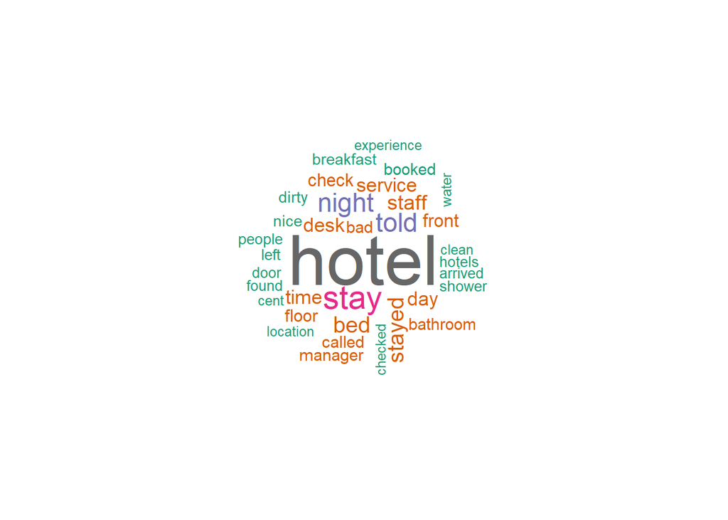

```r
rev %>%
  filter(sentiment == -1.5) %>%
  unnest_tokens(word, text) %>%
  anti_join(tidytext::stop_words, by = "word") %>%
  filter(!str_detect(word, "\\d")) %>%
  count(word) %>%
  with(
    wordcloud::wordcloud(
      word,
      n,
      max.words = 35,
      random.order = FALSE,
      colors = brewer.pal(8, "Dark2")
    )
  )
```

#### (g) Show a word cloud for the positive sentiment reviews (those coded as sentiment equal to 2.5) with stopwords removed.

#### Since *hotel* is not particularly informative, delete it as a stop word. (Use `anti_join(rbind("hotel", tidytext::stop_words))` at the stop words stage.)

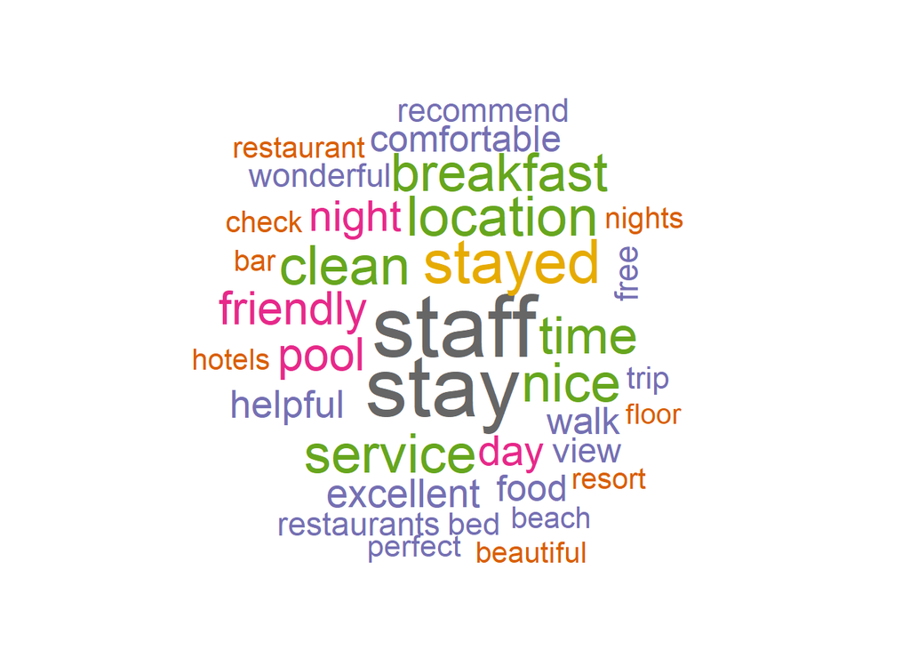

```r
rev %>%
  filter(sentiment == 2.5) %>%
  unnest_tokens(word, text) %>%
  anti_join(rbind("hotel", tidytext::stop_words), by = "word") %>%
  filter(!str_detect(word, "\\d")) %>%
  count(word) %>%
  with(
    wordcloud::wordcloud(
      word,
      n,
      max.words = 35,
      random.order = FALSE,
      colors = brewer.pal(8, "Dark2")
    )
  )
```

#### (h) We are interested in finding words that are most distinctive in each sentiment group.

#### We’re going to need to do some more cleaning. First, we need to filter out the reviews coded as -2.5 sentiment as these are not real reviews.

#### Second, we’re going to count the words, grouped by sentiment. To do this, use `count(sentiment, word, sort = TRUE)` which will count the word usage broken into sentiment categories. Display the top 25 terms sorted by tf-idf in descending order.

```r
rev %>%
  filter(sentiment != -2.5) %>%
  unnest_tokens(word, text) %>%
  # It's unclear in the question whether we should include the word "hotel" or not
  # anti_join(rbind("hotel", tidytext::stop_words, by = "word")) %>%
  anti_join(rbind(tidytext::stop_words, by = "word")) %>%
  count(sentiment, word, sort = TRUE) %>%
  group_by(sentiment) %>%
  mutate(total = sum(n)) %>%
  bind_tf_idf(word, sentiment, n) %>%
  arrange(-tf_idf) %>%
  head(25)
```

```
## # A tibble: 25 x 7
## # Groups:   sentiment [5]
##    sentiment word          n  total       tf   idf   tf_idf
##        <dbl> <chr>     <int>  <int>    <dbl> <dbl>    <dbl>
##  1      -1.5 i.i          11  24838 0.000443 1.61  0.000713
##  2       2.5 fantastic   291 123950 0.00235  0.223 0.000524
##  3       0.5 aviawest     11  46653 0.000236 1.61  0.000379
##  4       0.5 rosedale     10  46653 0.000214 1.61  0.000345
##  5       2.5 delicious    82 123950 0.000662 0.511 0.000338
##  6      -1.5 3br           5  24838 0.000201 1.61  0.000324
##  7      -1.5 alarms        5  24838 0.000201 1.61  0.000324
##  8      -0.5 funicular     5  26780 0.000187 1.61  0.000300
##  9       1.5 fantastic   128  98013 0.00131  0.223 0.000291
## 10      -0.5 rita          8  26780 0.000299 0.916 0.000274
## # ... with 15 more rows
```